# BEIS coffee and coding

Matthew Upson

2016-10-26

```r
knitr::opts_chunk$set(
  error = TRUE
  )
```

# Test Driven Development (TDD), with testthat and purrr

## BEIS Coffee and Coding

Imagine that we want to normalise a vector, which is a common task for machine learning.

Before setting out to write the code, there are a few things we already expect to be true of $\vec{y}$. We can list some of these expectations, for example:

- $\vec{y}$ should all be between $0$ and $1$
- $\vec{y}$ should be the same length as $\vec{x}$
- $\vec{x}$ should be scalar (`double` or `numeric` in R)

Let’s try this. First let’s create a vector x to play with based on a uniform distribution with a minimum of 10 and a maximum of 100

```r
x <- runif(100, min = 10, max = 100)

x
```

```
##   [1] 51.60209 85.41525 12.34862 68.07764 76.40719 53.32879 31.53466
##   [8] 48.04480 39.11604 43.91533 21.56281 15.98315 44.81736 69.57855
##  [15] 57.73163 90.67159 54.93983 25.42888 11.73478 79.36826 94.86652
##  [22] 74.60935 63.85302 65.65030 75.21001 78.50729 95.41150 72.71805
##  [29] 85.31082 42.97809 81.44050 88.27563 81.59731 64.99917 20.08639
##  [36] 16.94330 50.32214 51.98564 88.58484 61.63819 53.33723 56.07507
##  [43] 66.88344 17.14317 10.67798 64.95773 93.67473 68.77668 89.33798
##  [50] 64.99504 44.85787 36.66737 22.32634 47.51581 43.02638 54.18162
##  [57] 68.38669 57.72414 89.26547 70.35277 27.63452 53.78892 89.18587
##  [64] 89.42368 35.26846 71.59834 13.34378 21.34397 78.54891 30.61520
##  [71] 19.19921 27.54430 92.48771 42.95108 93.89893 34.82262 59.42257
##  [78] 16.57168 15.67036 65.66802 91.80163 37.79774 39.93987 45.73150
##  [85] 62.47521 13.03821 77.37439 59.93284 18.95590 16.95466 16.75053
##  [92] 42.90388 26.14253 68.74211 50.93855 44.76408 11.12847 22.27672
##  [99] 25.28180 17.18987
```

Now to normalise:

```r
y <- (x - min(x))/(max(x) - min(x))

y
```

```
##   [1] 0.482974276 0.882027166 0.019716443 0.677413836 0.775716740
##   [6] 0.503352236 0.246144340 0.440992125 0.335617641 0.392257382
##  [11] 0.128459501 0.062610021 0.402902835 0.695127093 0.555313308
##  [16] 0.944060982 0.522365301 0.174085710 0.012472012 0.810662392
##  [21] 0.993568266 0.754499121 0.627556111 0.648767134 0.761587916
##  [26] 0.800501492 1.000000000 0.732178636 0.880794791 0.381196361
##  [31] 0.835118316 0.915784534 0.836968982 0.641082633 0.111035275
##  [36] 0.073941459 0.467868725 0.487500853 0.919433817 0.601417331
##  [41] 0.503451849 0.535763024 0.663320241 0.076300265 0.000000000
##  [46] 0.640593560 0.979503086 0.685663697 0.928322057 0.641033961
##  [51] 0.403380909 0.306719056 0.137470473 0.434749229 0.381766217
##  [56] 0.513417111 0.681061196 0.555224868 0.927466364 0.704264296
##  [61] 0.200116052 0.508782580 0.926526931 0.929333518 0.290209625
##  [66] 0.718964107 0.031460979 0.125876857 0.800992733 0.235293200
##  [71] 0.100565087 0.199051356 0.965494330 0.380877539 0.982149026
##  [76] 0.284947897 0.575269310 0.069555707 0.058918647 0.648976187
##  [81] 0.957397333 0.320059373 0.345340216 0.413691256 0.611295622
##  [86] 0.027854753 0.787131353 0.581291277 0.097693592 0.074075473
##  [91] 0.071666434 0.380320566 0.182508045 0.685255699 0.475143369
##  [96] 0.402274040 0.005316488 0.136884899 0.172349964 0.076851367
```

Now we can test our assumptions:

What is the range of $\vec{y}$

```r
range(y)
```

```
## [1] 0 1
```

How long is $\vec{y}$?

```r
length(y)
```

```
## [1] 100
```

What class is $\vec{y}$?

```r
class(y)
```

```
## [1] "numeric"
```

All good so far, but this is quite long winded, and if we had to check that our code worked every time like this, we would have to write a lot of code. We would also start to break one of the tenets of good software development: *DRY* or *D*on’t *R*epeat *Y*ourself.

A better solution would be to generalise our code into a function. In this way we can hide away the complexities of the process, keeping our code nice and tidy, and just call our function every time we want to normalise something. This is also important when we come to talk about applying functions over a list using `purrr`.

But, we can go further than this. As well as formalising our code into a function, we can also formalise our testing process, so that these tests get completed automatically. This is the idea behind Test Driven Development, or TDD. The ‘Driven’ part is that we write out tests FIRST, not after we write the code we want to test. In this way, we formalise our expectations of what our code will do. The process then becomes that we write our test for a *unit* of code, these tests will fail until we write a complete function to whose output passes those tests. Only then do we move on to write the tests to the next unit, which of course will fail until we write our next unit of code.

`testthat` is a unit testing framework for R, which makes TDD very easy. Here I will re-use the normalisation example but with a TDD approach. First I define my tests, which encapsulate our expectations of what our code should do. Then I write a function to run our normalisation, thereby passing those tests.

A simple test from `testthat` looks like this:

```r
library(testthat)

expect_equal(
  range(normalise(x)),
  c(0, 1)
  )
```

This test encapsulates our expectation that after normalisation, our vector will have a minimum of $0$ and maximum of $1$.

Usually we want to package up a series of tests together to test a particular function. Here’s how we can do that:

```r
library(testthat)

test_that(
  "Test the normalise function",
  {

    # Tests run in their own environment, so we need to recreate a vector to test on:

    x <- runif(100, min = 10, max = 100)

    # Check that the min = 0 and the max = 1

    expect_equal(
      range(normalise(x)),
      c(0, 1)
    )

    # Check that y has the same length as x

    expect_equal(
      length(normalise(x)),
      length(x)
    )

    # Check that the resulting vector is numeric

    expect_is(
      range(normalise(x)),
      'numeric'
    )

    # Here I go one step further, and check the output against a specific and
    # easily checkable vector. I just did the sums in my head!

    test_vector = c(1, 2, 3)

    expect_equal(
      normalise(test_vector),
      c(0, 0.5, 1)
      )

  }
)
```

```
## Error: Test failed: 'Test the normalise function'
## * could not find function "normalise"
## 1: expect_equal(range(normalise(x)), c(0, 1)) at <text>:14
## 2: compare(object, expected, ...)
```

So we run this code, and the tests fail. Why? Because `could not find function "normalise"`. Of course - we have not written it yet!

So lets write it now. We define our function to take one input.

```r
normalise <- function(x) {

  # Run the normalisation as before

  y <- (x - min(x))/(max(x) - min(x))

  # Return the y object (if we didn't do this, nothing would happen!)

  return(y)

}
```

So with that written, lets try again with our tests.

```r
test_that(
  "Test the normalise function",
  {

    # Tests run in their own environment, so we need to recreate a vector to test on:

    x <- runif(100, min = 10, max = 100)

    # Check that the min = 0 and the max = 1

    expect_equal(
      range(normalise(x)),
      c(0, 1)
    )

    # Check that y has the same length as x

    expect_equal(
      length(normalise(x)),
      length(x)
    )

    # Check that the resulting vector is numeric

    expect_is(
      range(normalise(x)),
      'numeric'
    )

    # Here I go one step further, and check the output against a specific and
    # easily checkable vector. I just did the sums in my head!

    test_vector = c(1, 2, 3)

    expect_equal(
      normalise(test_vector),
      c(0, 0.5, 1)
      )

  }
)
```

This time we don’t get anything returned. These tests are silent. If they pass, they pass silently; if they fail they let us know.

So all good. At this point, we might start to think about the other ways that we might test our function. What would happen for instance if someone passed something to it that it was not expecting, for example:

- A single scalar instead of a vector.

How might we want our function to work in these case? Let’s say we want to handle this cases very simplistically by just returning an error We expand our test suite to include this:

```r
test_that(
  "Test the normalise function",
  {

    # Tests run in their own environment, so we need to recreate a vector to test on:

    x <- runif(100, min = 10, max = 100)

    # Check that the min = 0 and the max = 1

    expect_equal(
      range(normalise(x)),
      c(0, 1)
    )

    # Check that y has the same length as x

    expect_equal(
      length(normalise(x)),
      length(x)
    )

    # Check that the resulting vector is numeric

    expect_is(
      range(normalise(x)),
      'numeric'
    )

    # Here I go one step further, and check the output against a specific and
    # easily checkable vector. I just did the sums in my head!

    test_vector = c(1, 2, 3)

    expect_equal(
      normalise(test_vector),
      c(0, 0.5, 1)
      )

    # Add cases where we want to raise a warning

    expect_error(
      normalise(1)
      )

  }
)
```

```
## Error: Test failed: 'Test the normalise function'
## * normalise(1) did not throw an error.
```

These tests fail. Why? The error message says `normalise(1) did not throw an error`; so we know what we have to do…

```r
normalise <- function(x) {

  stopifnot(length(x) > 1)

  # Run the normalisation as before

  y <- (x - min(x))/(max(x) - min(x))

  # Return the y object (if we didn't do this, nothing would happen!)

  return(y)

}
```

Now that we have uodated the function, lets run the tests again…

```r
test_that(
  "Test the normalise function",
  {

    # Tests run in their own environment, so we need to recreate a vector to test on:

    x <- runif(100, min = 10, max = 100)

    # Check that the min = 0 and the max = 1

    expect_equal(
      range(normalise(x)),
      c(0, 1)
    )

    # Check that y has the same length as x

    expect_equal(
      length(normalise(x)),
      length(x)
    )

    # Check that the resulting vector is numeric

    expect_is(
      range(normalise(x)),
      'numeric'
    )

    # Here I go one step further, and check the output against a specific and
    # easily checkable vector. I just did the sums in my head!

    test_vector = c(1, 2, 3)

    expect_equal(
      normalise(test_vector),
      c(0, 0.5, 1)
      )

    # Add cases where we want to raise a warning

    expect_error(
      normalise(1)
      )

  }
)
```

So all the tests pass silently!

## Running functions over a list

R contains a myriad of functions for applying functions over its various data structures: `apply`, `sapply`, `tapply`, `vapply`, `mapply`, etc. Each is a minor variation on the theme.

`purrr` simplifies this somewhat by providing a simpler range of `map()`functions.

So let’s expand our TDD normalisation example. Imagine this scenario:

- We have a list of $n$ elements each containing a numeric vector.
- We want to normalise each vector in the list, without combining the data together (we’ll deal with this scenario later).

First lets create such a list. Actually it turns out that we can use `purrr` to help us create this list in the first place. Don’t worry if you don’t follow this just yet (you can always come back to this example once we have talked more about `purrr:map()`.

```r
library(purrr)
```

```r
# Map runs over each element of .x, and the anonymous function defined in .f
# uses these elements to set the elngth of the sequence of uniformly distributed
# numbers.

list_x <- purrr::map(.x = 2:10, .f = function(x) runif(x,min = 0, max = 10))

list_x
```

```
## [[1]]
## [1] 5.083860 6.746497
##
## [[2]]
## [1] 3.833580 6.998969 5.529238
##
## [[3]]
## [1] 5.078009 4.570473 6.055896 1.708706
##
## [[4]]
## [1] 7.692226 2.207001 4.335740 2.212711 7.316802
##
## [[5]]
## [1] 8.3259438 7.6992680 6.7595406 9.3911410 0.3151599 4.3544336
##
## [[6]]
## [1] 7.2519080 7.5393743 9.2637877 7.0593118 0.4563101 8.2820851 8.6687926
##
## [[7]]
## [1] 8.1320819 0.3016853 7.5782905 2.4516289 8.8327571 6.8279187 1.4244454
## [8] 3.7359203
##
## [[8]]
## [1] 1.116783 8.964898 1.551371 2.655593 2.133270 3.224366 7.050111 7.078245
## [9] 8.771895
##
## [[9]]
##  [1] 4.8778529 9.5722565 9.6723700 6.7997122 2.6645046 9.1069660 0.7304911
##  [8] 6.3762125 6.9725217 8.7962254
```

Just as I used `map()` to create this list, I can use it to normalise the items in the list.

```r
purrr::map(.x = list_x, .f = normalise)
```

```
## [[1]]
## [1] 0 1
##
## [[2]]
## [1] 0.000000 1.000000 0.535687
##
## [[3]]
## [1] 0.7750531 0.6583028 1.0000000 0.0000000
##
## [[4]]
## [1] 1.000000000 0.000000000 0.388086121 0.001041114 0.931557377
##
## [[5]]
## [1] 0.8826356 0.8135879 0.7100478 1.0000000 0.0000000 0.4450509
##
## [[6]]
## [1] 0.7715714 0.8042103 1.0000000 0.7497041 0.0000000 0.8885376 0.9324443
##
## [[7]]
## [1] 0.9178678 0.0000000 0.8529532 0.2520133 1.0000000 0.7649957 0.1316083
## [8] 0.4025561
##
## [[8]]
## [1] 0.00000000 1.00000000 0.05537483 0.19607382 0.12951987 0.26854641
## [7] 0.75601954 0.75960427 0.97540771
##
## [[9]]
##  [1] 0.4638132 0.9888040 1.0000000 0.6787411 0.2162871 0.9367690 0.0000000
##  [8] 0.6313798 0.6980670 0.9020178
```

We can see from the first element of the list that the values have been converted in $0$ and $1$: and since we have tested our function, we can be reasonably sure that it is doing what we expected.

But what if we don’t want to return a list at the end? There are a number of variants of `map()` that we can use instead. Probably most useful is `purrr::map_df()`, this will coerce our list into a dataframe, which tends to be a much more useful structure to use.

If we run it out of the box, it will fail, because the output of `normalise()` is not a `data.frame`:

```r
purrr::map_df(.x = list_x, .f = normalise)
```

```
## Error in eval(expr, envir, enclos): cannot convert object to a data frame
```

We can fix this by wrapping `normalise` into an anonymous function which converts the output to a `data.frame`.

```r
df_x <- purrr::map_df(
  .x = list_x,
  .f = function(x) data.frame(value = normalise(x)),
  .id = 'list_item'
  )

df_x
```

```
##    list_item       value
## 1          1 0.000000000
## 2          1 1.000000000
## 3          2 0.000000000
## 4          2 1.000000000
## 5          2 0.535687038
## 6          3 0.775053097
## 7          3 0.658302766
## 8          3 1.000000000
## 9          3 0.000000000
## 10         4 1.000000000
## 11         4 0.000000000
## 12         4 0.388086121
## 13         4 0.001041114
## 14         4 0.931557377
```

[output cut: 40 more lines]

So here we are returned a `data.frame` which contains all the items together in one column of the dataframe. An additional column (specified with `.id`) denotes which vector in the list a particular scalar has come from.

Of course, we know that we expect a `data.frame` to be the output of this bit of code, so we might have written a test for this beforehand with:

```r
test_that(
  'Test that map_df works with normalise',
  {

    # We expect df_x to be a dat.frame

    expect_is(
      df_x,
      'data.frame'
      )

    # We also know that the range of value should be 0, 1

    expect_equal(
      range(df_x$value),
      c(0, 1)
      )

    }
  )
```

The tests pass - all is good!

## Using purrr to iteratively apply models

One of the most useful things you can do with `purrr` is to apply a number of models over splits of a dataset. I exmplain this in a lot more detail on my blog http://www.machinegurning.com/rstats/iterating/, but I will give a brief overview of it here.

Here, I use the pipe (`%>%`) from package `dplyr`. If you’ve not seen this before, it operates very similarly to the linux pipe `|`, and just passes the output of one line of code to the input of the next line of code. There’s a lot of material available online about this, so I won’t try to replicate it - Google it!

So let’s start with the well known `mtcars` dataset. For info I will print it here:

```r
mtcars
```

```
##                      mpg cyl  disp  hp drat    wt  qsec vs am gear carb
## Mazda RX4           21.0   6 160.0 110 3.90 2.620 16.46  0  1    4    4
## Mazda RX4 Wag       21.0   6 160.0 110 3.90 2.875 17.02  0  1    4    4
## Datsun 710          22.8   4 108.0  93 3.85 2.320 18.61  1  1    4    1
## Hornet 4 Drive      21.4   6 258.0 110 3.08 3.215 19.44  1  0    3    1
## Hornet Sportabout   18.7   8 360.0 175 3.15 3.440 17.02  0  0    3    2
## Valiant             18.1   6 225.0 105 2.76 3.460 20.22  1  0    3    1
## Duster 360          14.3   8 360.0 245 3.21 3.570 15.84  0  0    3    4
## Merc 240D           24.4   4 146.7  62 3.69 3.190 20.00  1  0    4    2
## Merc 230            22.8   4 140.8  95 3.92 3.150 22.90  1  0    4    2
## Merc 280            19.2   6 167.6 123 3.92 3.440 18.30  1  0    4    4
## Merc 280C           17.8   6 167.6 123 3.92 3.440 18.90  1  0    4    4
## Merc 450SE          16.4   8 275.8 180 3.07 4.070 17.40  0  0    3    3
## Merc 450SL          17.3   8 275.8 180 3.07 3.730 17.60  0  0    3    3
## Merc 450SLC         15.2   8 275.8 180 3.07 3.780 18.00  0  0    3    3
## Cadillac Fleetwood  10.4   8 472.0 205 2.93 5.250 17.98  0  0    3    4
## Lincoln Continental 10.4   8 460.0 215 3.00 5.424 17.82  0  0    3    4
## Chrysler Imperial   14.7   8 440.0 230 3.23 5.345 17.42  0  0    3    4
## Fiat 128            32.4   4  78.7  66 4.08 2.200 19.47  1  1    4    1
## Honda Civic         30.4   4  75.7  52 4.93 1.615 18.52  1  1    4    2
## Toyota Corolla      33.9   4  71.1  65 4.22 1.835 19.90  1  1    4    1
## Toyota Corona       21.5   4 120.1  97 3.70 2.465 20.01  1  0    3    1
## Dodge Challenger    15.5   8 318.0 150 2.76 3.520 16.87  0  0    3    2
## AMC Javelin         15.2   8 304.0 150 3.15 3.435 17.30  0  0    3    2
## Camaro Z28          13.3   8 350.0 245 3.73 3.840 15.41  0  0    3    4
## Pontiac Firebird    19.2   8 400.0 175 3.08 3.845 17.05  0  0    3    2
## Fiat X1-9           27.3   4  79.0  66 4.08 1.935 18.90  1  1    4    1
## Porsche 914-2       26.0   4 120.3  91 4.43 2.140 16.70  0  1    5    2
## Lotus Europa        30.4   4  95.1 113 3.77 1.513 16.90  1  1    5    2
## Ford Pantera L      15.8   8 351.0 264 4.22 3.170 14.50  0  1    5    4
## Ferrari Dino        19.7   6 145.0 175 3.62 2.770 15.50  0  1    5    6
## Maserati Bora       15.0   8 301.0 335 3.54 3.570 14.60  0  1    5    8
## Volvo 142E          21.4   4 121.0 109 4.11 2.780 18.60  1  1    4    2
```

You can read about the data by running `?mtcars`, but essentially it describes the characteristics of a number of classic cars.

Lets say that we want to apply a model to these data, and we have a hunch that miles per gallon (`mpg`) is correlated with the weight of the car `wt`. We can produce a single linear model like so:

```r
model <- lm(mpg ~ wt, data = mtcars)
summary(model)
```

```
##
## Call:
## lm(formula = mpg ~ wt, data = mtcars)
##
## Residuals:
##     Min      1Q  Median      3Q     Max
## -4.5432 -2.3647 -0.1252  1.4096  6.8727
##
## Coefficients:
##             Estimate Std. Error t value Pr(>|t|)
## (Intercept)  37.2851     1.8776  19.858  < 2e-16 ***
## wt           -5.3445     0.5591  -9.559 1.29e-10 ***
## ---
## Signif. codes:  0 '***' 0.001 '**' 0.01 '*' 0.05 '.' 0.1 ' ' 1
##
## Residual standard error: 3.046 on 30 degrees of freedom
## Multiple R-squared:  0.7528, Adjusted R-squared:  0.7446
## F-statistic: 91.38 on 1 and 30 DF,  p-value: 1.294e-10
```

All very simple stuff. And if we want to plot it, thats easy too:

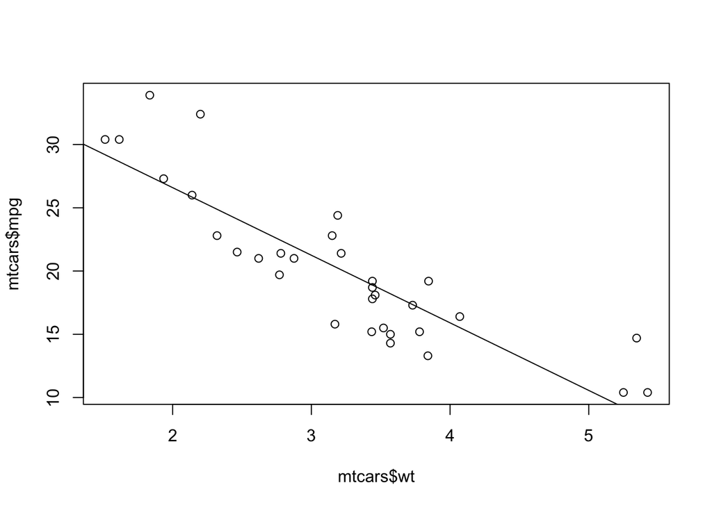

```r
plot(mtcars$wt,mtcars$mpg)
abline(model)
```

So far so good. Now lets say we have an interest in the number of cylinders that the cars have, and we want to run a model for every number of cylinders that a car might have. We can do this by slitting the `mtcars` dataset over `cyl`.

```r
mtcars %>%
  split(.$cyl)
```

```
## $`4`
##                 mpg cyl  disp  hp drat    wt  qsec vs am gear carb
## Datsun 710     22.8   4 108.0  93 3.85 2.320 18.61  1  1    4    1
## Merc 240D      24.4   4 146.7  62 3.69 3.190 20.00  1  0    4    2
## Merc 230       22.8   4 140.8  95 3.92 3.150 22.90  1  0    4    2
## Fiat 128       32.4   4  78.7  66 4.08 2.200 19.47  1  1    4    1
## Honda Civic    30.4   4  75.7  52 4.93 1.615 18.52  1  1    4    2
## Toyota Corolla 33.9   4  71.1  65 4.22 1.835 19.90  1  1    4    1
## Toyota Corona  21.5   4 120.1  97 3.70 2.465 20.01  1  0    3    1
## Fiat X1-9      27.3   4  79.0  66 4.08 1.935 18.90  1  1    4    1
## Porsche 914-2  26.0   4 120.3  91 4.43 2.140 16.70  0  1    5    2
## Lotus Europa   30.4   4  95.1 113 3.77 1.513 16.90  1  1    5    2
## Volvo 142E     21.4   4 121.0 109 4.11 2.780 18.60  1  1    4    2
##
## $`6`
##                 mpg cyl  disp  hp drat    wt  qsec vs am gear carb
## Mazda RX4      21.0   6 160.0 110 3.90 2.620 16.46  0  1    4    4
## Mazda RX4 Wag  21.0   6 160.0 110 3.90 2.875 17.02  0  1    4    4
## Hornet 4 Drive 21.4   6 258.0 110 3.08 3.215 19.44  1  0    3    1
## Valiant        18.1   6 225.0 105 2.76 3.460 20.22  1  0    3    1
## Merc 280       19.2   6 167.6 123 3.92 3.440 18.30  1  0    4    4
## Merc 280C      17.8   6 167.6 123 3.92 3.440 18.90  1  0    4    4
## Ferrari Dino   19.7   6 145.0 175 3.62 2.770 15.50  0  1    5    6
##
## $`8`
##                      mpg cyl  disp  hp drat    wt  qsec vs am gear carb
## Hornet Sportabout   18.7   8 360.0 175 3.15 3.440 17.02  0  0    3    2
## Duster 360          14.3   8 360.0 245 3.21 3.570 15.84  0  0    3    4
## Merc 450SE          16.4   8 275.8 180 3.07 4.070 17.40  0  0    3    3
## Merc 450SL          17.3   8 275.8 180 3.07 3.730 17.60  0  0    3    3
## Merc 450SLC         15.2   8 275.8 180 3.07 3.780 18.00  0  0    3    3
## Cadillac Fleetwood  10.4   8 472.0 205 2.93 5.250 17.98  0  0    3    4
## Lincoln Continental 10.4   8 460.0 215 3.00 5.424 17.82  0  0    3    4
## Chrysler Imperial   14.7   8 440.0 230 3.23 5.345 17.42  0  0    3    4
## Dodge Challenger    15.5   8 318.0 150 2.76 3.520 16.87  0  0    3    2
## AMC Javelin         15.2   8 304.0 150 3.15 3.435 17.30  0  0    3    2
## Camaro Z28          13.3   8 350.0 245 3.73 3.840 15.41  0  0    3    4
## Pontiac Firebird    19.2   8 400.0 175 3.08 3.845 17.05  0  0    3    2
## Ford Pantera L      15.8   8 351.0 264 4.22 3.170 14.50  0  1    5    4
## Maserati Bora       15.0   8 301.0 335 3.54 3.570 14.60  0  1    5    8
```

You can see that this code has returned me a list of three `data.frames` each with a different number of `cyl`.

Now that we have this in a list, we can start to use `purrr::map()` in the same way as before to run an operation on each of the elements of the list. In this case, a linear model. Note that we need to use `.` to denote where we want our data to go, as the pipe will always look to insert its data into the first argument, unless we explicitly tell it where we want it to go:

```r
mtcars %>%
  split(.$cyl) %>%
  map(~ lm(mpg ~ wt, data = .))
```

```
## $`4`
##
## Call:
## lm(formula = mpg ~ wt, data = .)
##
## Coefficients:
## (Intercept)           wt
##      39.571       -5.647
##
##
## $`6`
##
## Call:
## lm(formula = mpg ~ wt, data = .)
##
## Coefficients:
## (Intercept)           wt
##       28.41        -2.78
##
##
## $`8`
##
## Call:
## lm(formula = mpg ~ wt, data = .)
##
## Coefficients:
## (Intercept)           wt
##      23.868       -2.192
```

Here we are now returned the coefficients from the three models. This output is not very inoformative, really we want to apply the summary method to each of these models, so we can just chain another `map` call on to the end to do this:

```r
mtcars %>%
  split(.$cyl) %>%
  map(~ lm(mpg ~ wt, data = .)) %>%
  map(summary)
```

```
## $`4`
##
## Call:
## lm(formula = mpg ~ wt, data = .)
##
## Residuals:
##     Min      1Q  Median      3Q     Max
## -4.1513 -1.9795 -0.6272  1.9299  5.2523
##
## Coefficients:
##             Estimate Std. Error t value Pr(>|t|)
## (Intercept)   39.571      4.347   9.104 7.77e-06 ***
## wt            -5.647      1.850  -3.052   0.0137 *
## ---
## Signif. codes:  0 '***' 0.001 '**' 0.01 '*' 0.05 '.' 0.1 ' ' 1
##
## Residual standard error: 3.332 on 9 degrees of freedom
## Multiple R-squared:  0.5086, Adjusted R-squared:  0.454
## F-statistic: 9.316 on 1 and 9 DF,  p-value: 0.01374
##
##
## $`6`
##
## Call:
## lm(formula = mpg ~ wt, data = .)
##
## Residuals:
##      Mazda RX4  Mazda RX4 Wag Hornet 4 Drive        Valiant       Merc 280
##        -0.1250         0.5840         1.9292        -0.6897         0.3547
##      Merc 280C   Ferrari Dino
##        -1.0453        -1.0080
##
## Coefficients:
##             Estimate Std. Error t value Pr(>|t|)
## (Intercept)   28.409      4.184   6.789  0.00105 **
## wt            -2.780      1.335  -2.083  0.09176 .
## ---
## Signif. codes:  0 '***' 0.001 '**' 0.01 '*' 0.05 '.' 0.1 ' ' 1
##
## Residual standard error: 1.165 on 5 degrees of freedom
```

[output cut: 8 more lines]

```
##
## Residuals:
##     Min      1Q  Median      3Q     Max
## -2.1491 -1.4664 -0.8458  1.5711  3.7619
##
## Coefficients:
##             Estimate Std. Error t value Pr(>|t|)
## (Intercept)  23.8680     3.0055   7.942 4.05e-06 ***
## wt           -2.1924     0.7392  -2.966   0.0118 *
## ---
## Signif. codes:  0 '***' 0.001 '**' 0.01 '*' 0.05 '.' 0.1 ' ' 1
##
## Residual standard error: 2.024 on 12 degrees of freedom
## Multiple R-squared:  0.423,  Adjusted R-squared:  0.3749
## F-statistic: 8.796 on 1 and 12 DF,  p-value: 0.01179
```

And lets say we are only really interested in the $R^2$, well, we can extract this too. If we just pass an element of the list to the `map` command, it will print it by default, instead of applying a function.

```r
mtcars %>%
  split(.$cyl) %>%
  map(~ lm(mpg ~ wt, data = .)) %>%
  map(summary) %>%
  map("r.squared")
```

```
## $`4`
## [1] 0.5086326
##
## $`6`
## [1] 0.4645102
##
## $`8`
## [1] 0.4229655
```

So finally we get the three $R^2$ values of the models, and we can keep going. If we want all these elements rounded, and coerced into a numeric vector (rather than a list), we can use `map_dbl`.

```r
mtcars %>%
  split(.$cyl) %>%
  map(~ lm(mpg ~ wt, data = .)) %>%
  map(summary) %>%
  map("r.squared") %>%
  map_dbl(~round(.x, 2))
```

```
##    4    6    8
## 0.51 0.46 0.42
```

For more detail on this, I encurage you to read my blog post: http://www.machinegurning.com/rstats/iterating/